# Final Project: The Economics of Football

Asger, Laurits, Sejer og Nikolaj

2025-05-19

## Introduction

This project revolves around international football and its economics. Specifically are we focusing on the transfer fees between the players from the season of 1924/1925 up until this season of 2024/2025. We are covering the top-10-transfers every season. With that are we looking into the cost development of said transfers.

First of all are we going to load tidyverse and other necessary packages.

```r
library(tidyverse)
library(ggplot2)
library(readr)
library(dplyr)
library(scales)
```

## Loading our data

Afterwards we need to load our own dataset into R.

```
## # A tibble: 101 × 13
##    Season   nr.1  nr.2  nr.3 nr.4  nr.5  nr.6  nr.7  nr.8  nr.9  nr.10 Average
##    <chr>   <dbl> <dbl> <dbl> <chr> <chr> <chr> <chr> <chr> <chr> <chr>   <dbl>
##  1 1924/25  5000  4000  3000 2000  1000  1000  720   600   500   450      1827
##  2 1925/26  7000  7000  6000 5000  5000  4000  3000  3000  3000  3000     4600
##  3 1926/27  8000  4000  4000 4000  3000  3000  3000  2000  2000  2000     3500
##  4 1927/28  5000  4000  3000 3000  3000  1000  1000  1000  1000  700      2270
##  5 1928/29 13000  8000  8000 5000  4000  4000  4000  3000  2000  1000     5200
##  6 1929/30 12000  9000  7000 6000  6000  6000  5000  5000  4000  4000     6400
##  7 1930/31  7000  3000   901 880   640   600   525   520   500   350      1492
##  8 1931/32 27000  6000  6000 4000  3000  3000  3000  1000  1000  1000     5500
##  9 1932/33  4000  3000  3000 3000  3000  3000  2000  1000  1000  1000     2400
## 10 1933/34 43000 20000 10000 8000  7000  7000  5000  3000  3000  2000    10800
## # ℹ 91 more rows
## # ℹ 1 more variable: Valuta <chr>
```

## Plotting our data

Now we are going to make a basic graph showing the development of the costs using ggplot. To do this we have elected the help of ChatGPT to tidy up our code, so that we have colourful themes and breaks between the seasons in the X-axis. ChatGPT also recommended converting our coloumn “Average” into a numeric value.

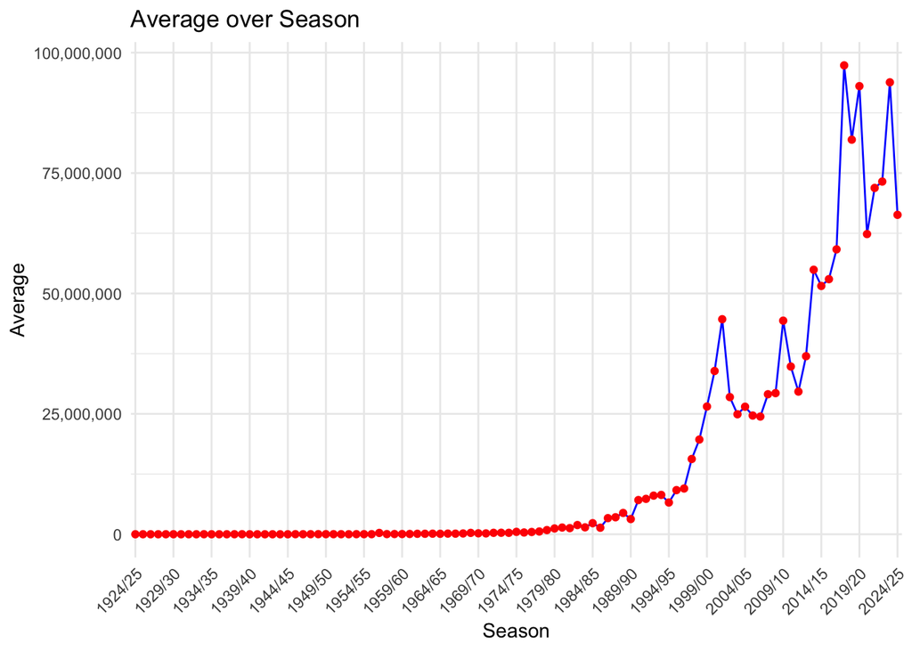

## Getting the statistics

We wanted to get some basic statistics from the graphs. Like the maximum, overall average fee and so on. It is just to gather a overview of the statistics that we are dealing with. To do that are going to use basic R commands from the Data Carpentry, and tidying it in ChatGPT to visualise it better with the cat() command.

```
## Max value: 2.22e+08
```

```
## Min value: 15
```

```
## Average (mean): 14540987
```

```
## Median: 455000
```

```
##  [1] 222000000 180000000 135000000 135000000 127200000 121000000 120800000
##  [8] 120000000 117500000 117000000
```

The max value is 2.22e+08, which also translates to 222.000.000. Along with that we also wanted to show the top 10 transfer fees across all seasons.

## Analyzing time periods

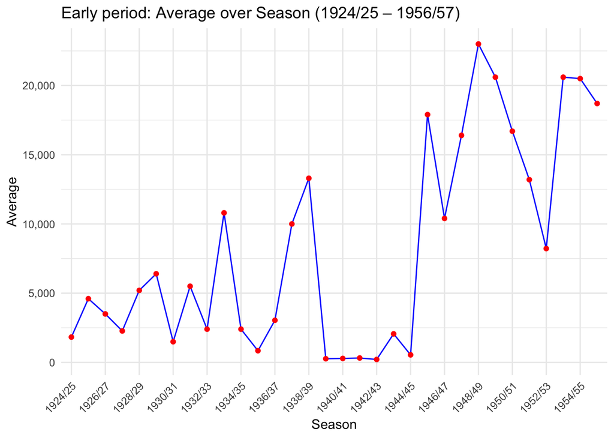

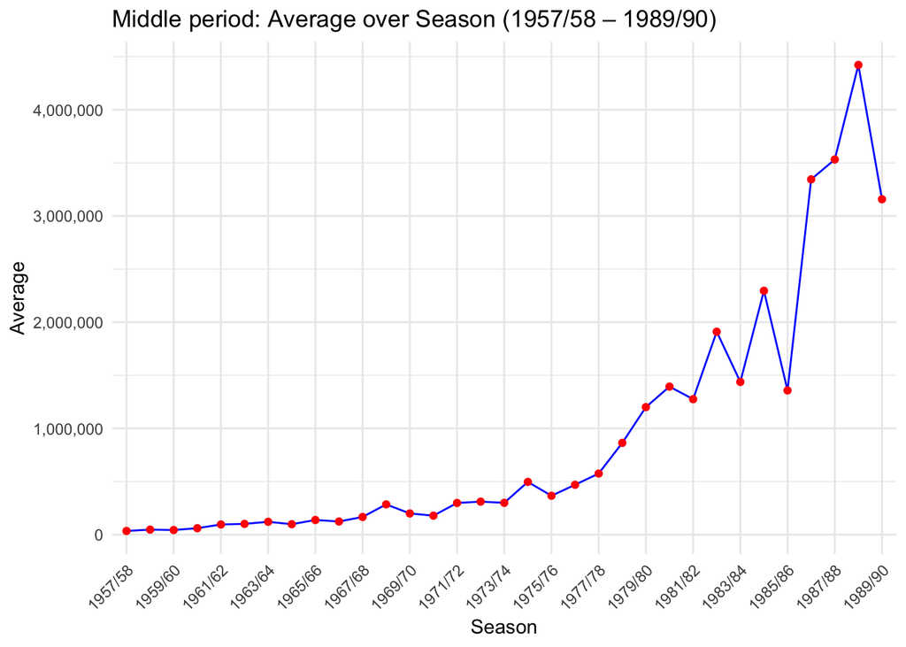

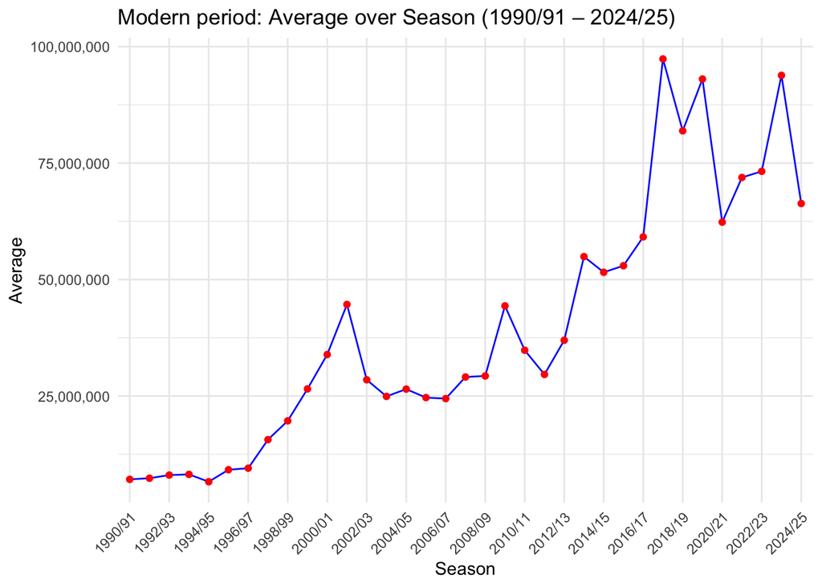

## Playing with percentages

To understand the data better we are going to convert the price changes per year into percentage, so that the data is more comparable. To do that we mutated the data, so that we would have a new coloumn of data with the data percentages. The command “lag(Average)” means the former seasons average, thereafter we calculate the difference and make it a percentile.

```
## # A tibble: 101 × 2
##    Season  PercentChange
##    <chr>           <dbl>
##  1 1924/25          NA
##  2 1925/26         152.
##  3 1926/27         -23.9
##  4 1927/28         -35.1
##  5 1928/29         129.
##  6 1929/30          23.1
##  7 1930/31         -76.7
##  8 1931/32         269.
##  9 1932/33         -56.4
## 10 1933/34         350
## # ℹ 91 more rows
```

After loading the percentages per season, we want to visualise it in a graph. The 1924/1925 value is NA, because the data is comparing to the earlier season. We wanted to make a graph that showed the growth and fall in percentile each season. So based on the data calculated above, we had ChatGPT visualise it with a ggplot. Like earlier we wanted it to correspond with the periods that we had set up, so it was split into three.

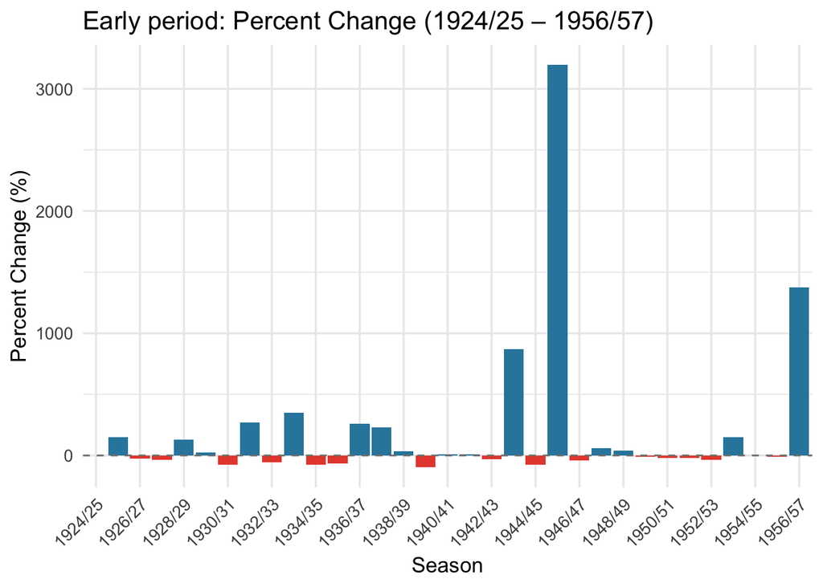

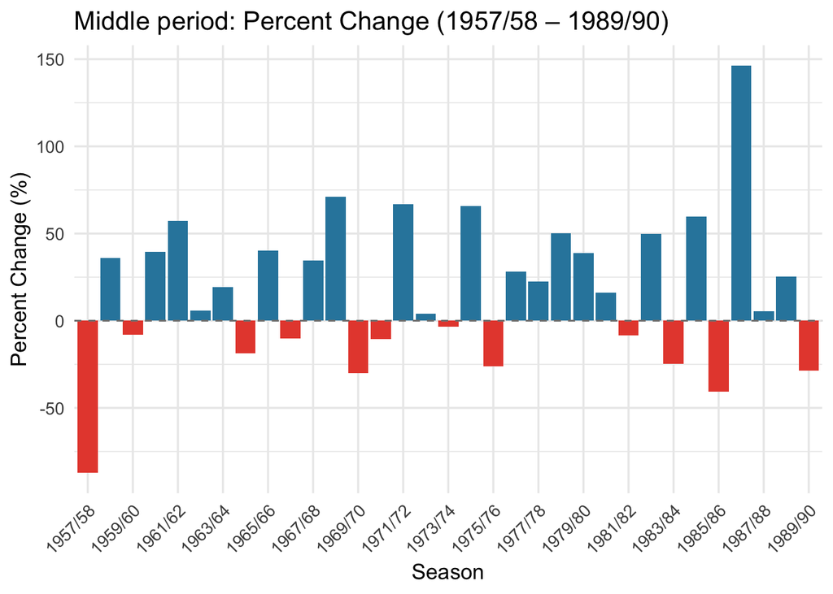

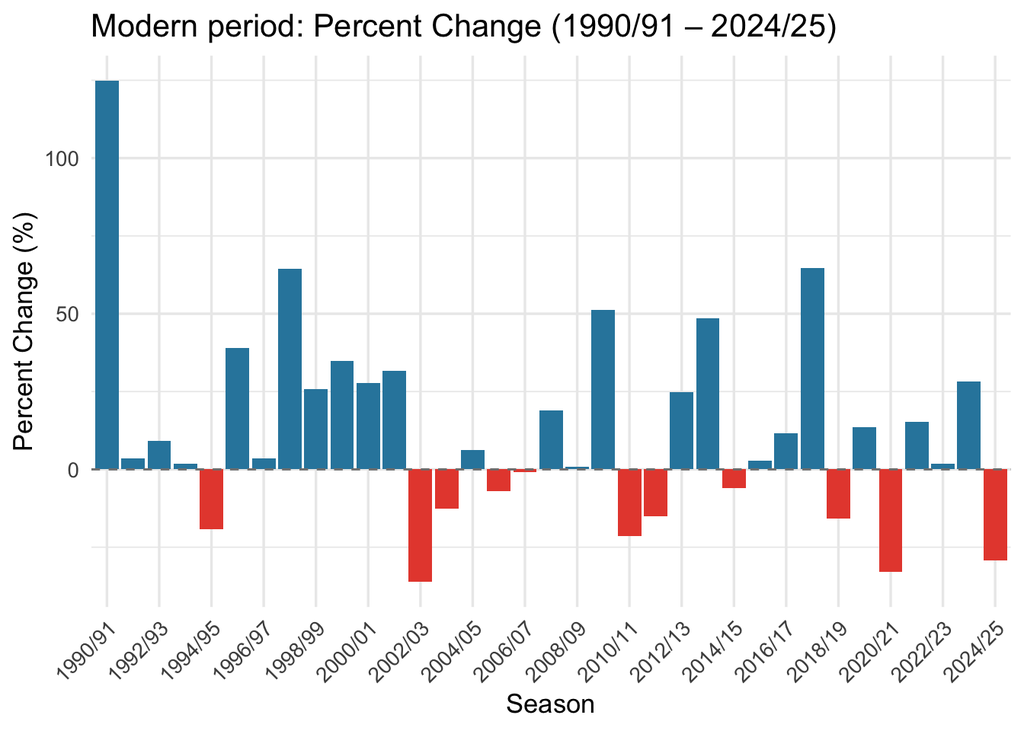

## Comparing data from the World GDP and our data.

We have looked at the World Bank and its data on development of the World’s GDP since 1960. We want to compare this data with our own to see if there are any comparable tendencies between the World’s GDP and the economics of football. We had made a new dataset, with the help of ChatGPT and the World Bank. Afterwards we used ChatGPT to use the same format on the graph like we had earlier with the transfer fees.

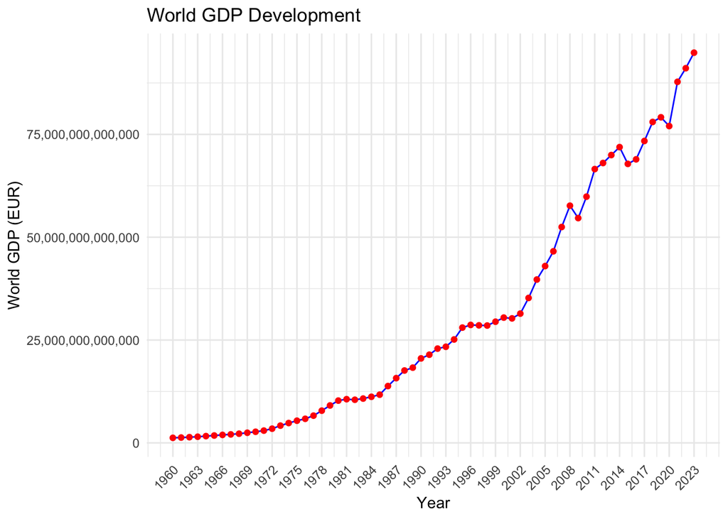

Next we wanted to use ChatGPT to overlay the two datasets so it became more easily comparable and gave a nice tidy version of it together.

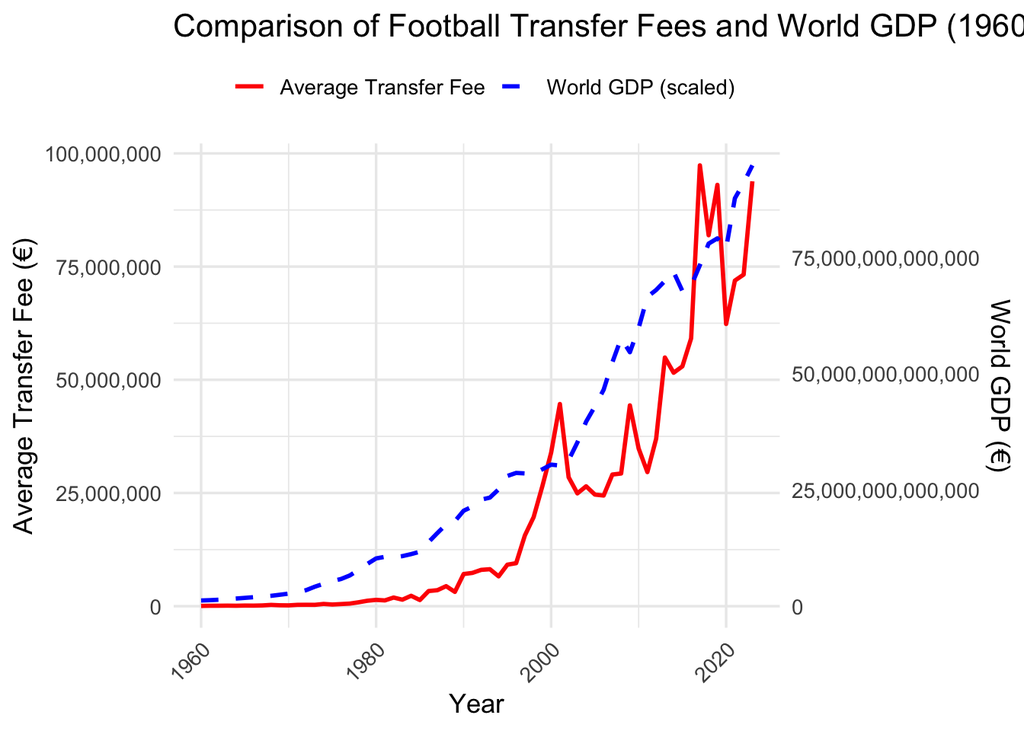

## Financial crisis vs. Football economics

We can see from the graph above that the two economies follow eachother to some extent. So we wanted to explore this futher, and included major econonimic crisis into the graph, so we could getter picture of the influence those had on both the World’s GDP and the transfer fees. We have included the Oil Crisis of 1973, the recession in the 1980’s, Black Monday in 1987, Asian Financial Crisis in 1997, the Dot-com crash in 2000, the Wall Street crash in 2008, the Eurozone crisis in 2010, COVID-19 in 2020 and the Energy Crisis in 2022.

We wanted to make two graphs, one similar to the one above and another one where we compare the changes in percentages. So we asked ChatGPT to make the two graphs based on our earlier templates with the percentile changes per season and the one just above. We wanted a X-axis with only the crisis years and a marker in the graph, so that it was tidy and easily readable.

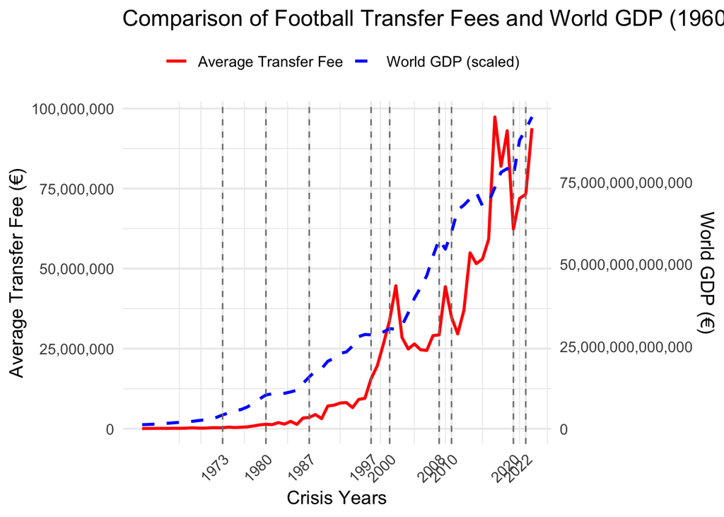

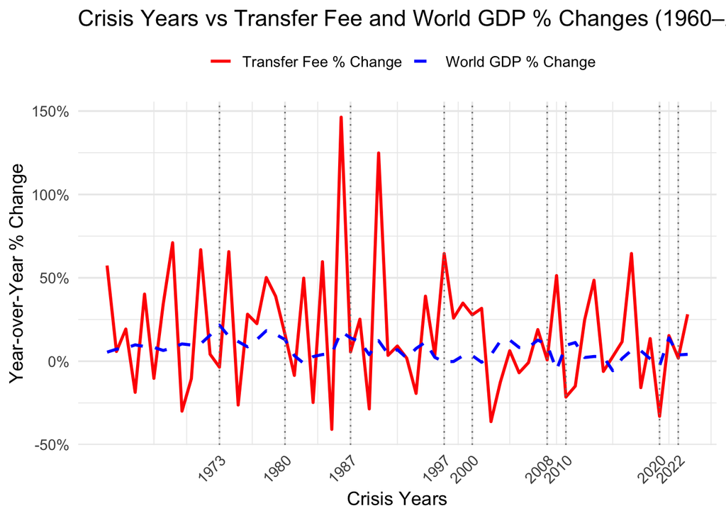

You can clearly see some tendencies that correlate to eachother. It is especially clear with the graph showcasing the percentile changes, as nearly all economic crisis saw a dip in the transfer fee percent change compared to the year before. The figure that shows the comparison between the fees and World’s GDP shows some clear falls in the fees revolving the crisis after the year 2000, but did not look to have an impact beforehand.